# Wolf abundance

[NO_WOAB_001]

Author

Affiliation

Aud H. Halbritter

University of Bergen

Published

May 15, 2026

> **Recommended citation**: Halbritter, A. H. 2026. Wolf abundance [Ulvebestand] (ID(s): NO_WOAB_001) v. 0.1.0. ecRxiv: https://github.com/NINAnor/ecRxiv/tree/main/indicators/NO_WOAB_001

**TipMetadata**

Table 1: Indicator metadata

| Variable | Value |
| --- | --- |
| Indicator ID | NO_WOAB_001 |
| Indicator Name | Wolf abundance [Ulvebestand] |
| Country | Norway |
| Continent | Europe |
| Ecosystem Condition Typology Class | B3 Functional state characteristics |
| Realm | Terrestrial (T) |
| Biome | T2 Temperate-boreal forests and woodlands biome |
| Ecosystem | T2.1 Boreal/montane forests |
| Year added | 2026 |
| Last update | 2026 |
| Version | 0.1.0 |
| Version comment | First version on ecRxiv; indicator described in the Norwegian Nature Index |
| Normalised | TRUE |
| Spatial aggregation pathway | Aggregate (population model, large-carnivore management region) - [Scale - Truncate] - Aggregate (national level) |

**TipLog**

- May 15, 2026 - Initial draft for ecRxiv

## 2. About the underlying data

### 2.1 Spatial and temporal resolution and extent

Indicator values are available for the assessment years in Naturindeksen: 1990, 2000, 2010, 2014, 2019, and 2024.

To produce indicator estimates for these years, input is combined over a short window (typically two to three years), as specified in the Naturindeks indicator protocol.

Spatially, data are organised by the eight large-carnivore management regions (*forvaltningsregioner for rovvilt*, regions 1–8). In Naturindeksen, indicator and reference values are stored at management-region scale (IC units), then aggregated to five geographic regions and national level for reporting, using the same spatial framework as for brown bear and lynx in this repository.

### 2.2 Sampling design

[Rovdata](https://rovdata.no/Ulv.aspx) is responsible for monitoring wolves in Norway and for maintaining an overview of how many wolves there are in the country. Populations are estimated from annual winter monitoring, including counts of wolves with wholly Norwegian residency and wolves with residency on both sides of the border with Sweden, and reporting of wolf litters in Norwegian and border territories relative to national targets (Rovdata 2025). Further detail on field methods (for example registration of tracks and signs) is linked from [Rovdata](https://rovdata.no/Ulv.aspx).

### 2.3 Original units

At the monitoring stage, Rovdata reports population status using numbers of wolves (including ranges for a given winter) and documentation of litters in territories (Rovdata 2025).

### 2.4 Instructions for citing, using and accessing data

Population monitoring and status information: cite [Rovdata](https://rovdata.no/Ulv.aspx) and the relevant status pages (Rovdata 2025). Methodological documentation for the indicator: [Naturindeksen – ulv](https://naturindeks.no/Indicators/ulv).

## 3. Indicator properties

### 3.1 Ecosystem Condition Typology Class (ECT)

B3 – Functional state characteristics.

### 3.2 Ecosystem condition characteristic

### 3.3 Collinearities with other indicators

The indicator may covary with other large-carnivore indicators that use the same regional structure (brown bear, lynx, wolverine) where distributions overlap.

### 3.4 Impact factors

### 3.5 Spatial aggregation

Following the metadata pathway Aggregate (population model, large-carnivore management region) – [Scale – Truncate] – Aggregate (national level): values are handled per forvaltningsregion for rovvilt in Naturindeksen, then aggregated to five geographic regions and national level with area weights (see Section 8). Each unit is normalised against *X<sub>0</sub>* and *X<sub>100</sub>* for that region (linear scaling with truncation to [0, 1]).

## 4. Reference condition and levels

### 4.1 Reference condition

The reference condition for wolf in Naturindeksen is a boreal/montane forest ecosystem with minimal human impact and a climate similar to the reference period used in the Norwegian Nature Index framework (Nybø et al. 2017).

### 4.2 Reference levels

*X<sub>100</sub>* is set per large-carnivore management region (IC unit in Naturindeksen), using suitable area and density within each *rovviltregion* and expert assessment: it represents the expected wolf population (or equivalent index) under reference conditions in that unit.

*X<sub>0</sub>* is defined as no wolves in the unit (functional absence).

#### 4.2.1 Spatial resolution and validity

Reference levels and indicator values apply at the scale of forvaltningsregioner for rovvilt (IC units). Aggregated results for the five Naturindeks geographic regions and for Norway are summaries of those units with area weights.

## 5. Uncertainties

### 5.1 General uncertainties

Reference levels are held fixed in this workflow (their own uncertainties are not propagated). Regional and national values are area-weighted summaries of forvaltningsregioner for rovvilt, so they inherit model uncertainty at management-region scale and any mismatch between administrative regions and ecological variation within the five Naturindeks geographic regions. Monitoring design and sample effort differ between species and regions; uneven coverage can affect the population models that enter Naturindeksen.

### 5.2 Reported uncertainties

The intervals in Table 2 and Figure 2 are inferential: they describe uncertainty around the estimated area-weighted mean indicator for each reporting unit (a geographic region or Norway as a whole), given the statistical models used for management-region abundance in Naturindeksen.

## 6. References

Norwegian Institute for Nature Research, and partners. 2025. “Norwegian Nature Index (Naturindeks).” https://www.naturindeks.no.

Nybø, Signe et al. 2017. “Fagsystem for Naturindeks: Referansetilstand Og Skalering.” Norwegian Institute for Nature Research (NINA).

Rovdata. 2025. “Bestandsstatus: Ulv.” https://rovdata.no/Ulv/Bestandsstatus.aspx.

## 7. Import and prepare datasets

Run the download chunk once to refresh the local export. This project’s renv environment installs `NIcalc` from GitHub `ChloeRN/NIcalc`, branch `include_ReadOnly_access` (see `renv.lock` and `install_deps.R`); that build defaults to the Naturindeks read-only API user, so you do not need `username` / `password` arguments here. When [NINAnor/NIcalc PR #59](https://github.com/NINAnor/NIcalc/pull/59) is merged into `NINAnor/NIcalc`, you can switch the renv install back to the main repo and update the lockfile. We save the RDS export under `data/` so that we do not need to download the data every time we run the analysis.

**Download wolf data from Naturindeks API**

```r
woabImport <- NIcalc::importDatasetApi(
  eco = NULL,
  indic = c("Ulv"),
  year = c("1990", "2000", "2010", "2014", "2019", "2024")
)

saveRDS(woabImport, here::here("data/woabImport.rds"))
```

## 8. Spatial units

The eight forvaltningsregioner for rovvilt (rovvilt regions 1–8) are the IC units in Naturindeks for this indicator. The five Naturindeks geographic regions (east, south, west, central, north; codes E, S, W, C, N) are built from those management regions using the mapping in `R/spatial_regions.R`. Mainland Norway is the ecosystem accounting area.

## 9. Analyses

This section takes variable values and reference levels from the Naturindeks import, normalises at management-region scale with linear scaling, then propagates uncertainty and aggregates spatially with terrestrial area weights. At geographic-region and national scale, uncertainties are inferential: each replicate is an area-weighted mean based on one draw per management region (then per geographic region), not a random draw from a pooled mixture of regions.

Management-region population indices in the database are stored as predictive distributions, not only as point estimates. Reference levels per region (*X<sub>0</sub>* = 0, *X<sub>100</sub>* from the download) are applied before any geographic or national aggregation. We ignore uncertainty in the reference levels themselves.

### Assemble import and indicator object

`assembleNiObject()` reshapes `woabImport` so that indicator observations are in one list element per assessment year, and so that underlying spatial units (`BSunits`) are aligned with the thematic index structure used in Naturindeks.

**Assemble wolf NI object (thematic, predefined regions)**

```r
woabAssemble <- NIcalc::assembleNiObject(
  inputData = woabImport,
  predefNIunits = c(allArea = T, parts = T, counties = F),
  indexType = "thematic"
)
```

```
Check input data .....
```

```
Elicitate incomplete reference values and indicator observations .....
```

```
Assemble dataset .....
```

### Reference levels (X<sub>0</sub> and X<sub>100</sub>)

Before scaling, we read regional reference levels from `referenceValues` in the RDS export (rows with `yearId == 0` or reference year name). For this indicator, *X<sub>0</sub>* is zero individuals in the unit and *X<sub>100</sub>* is the expert reference population index per rovvilt region (`expectedValue` in the reference slice).

**Management-region reference levels from downloaded Naturindeks data**

```r
refs <- woabImport$referenceValues$referenceValues |>
  dplyr::filter(.data$yearId == 0L | grepl("Referanse", .data$yearName, fixed = FALSE)) |>
  dplyr::distinct(ICunitId, ICunitName, x100 = expectedValue) |>
  dplyr::mutate(x0 = 0)
refs |>
  gt::gt()
```

| ICunitId | ICunitName | x100 | x0 |
| --- | --- | --- | --- |
| 3793 | Rovviltregion 8 | 528 | 0 |
| 3795 | Rovviltregion 7 | 248 | 0 |
| 3796 | Rovviltregion 6 | 412 | 0 |
| 3799 | Rovviltregion 1 | 287 | 0 |
| 3803 | Rovviltregion 2 | 287 | 0 |
| 3807 | Rovviltregion 3 | 163 | 0 |
| 3809 | Rovviltregion 4 | 44 | 0 |
| 3811 | Rovviltregion 5 | 202 | 0 |

### Resample non-scaled management-region variables

For each assessment year, Naturindeks stores one value per rovvilt region as a parameterised distribution (or a custom distribution). We draw `nsim = 1000` random values per region with `NIcalc::sampleObsMat()`. Rows with a standard distribution family use observation type `tradObs`; rows with only a custom distribution use `customObs`.

Assessment years are 1990, 2000, 2010, 2014, 2019, and 2024. The result `dat` is a long table of simulated population indices (`value`) by `ICunitId` and `year`, not yet on the 0–1 indicator scale.

**Observation types for sampleObsMat**

```r
myYears <- as.character(c(1990, 2000, 2010, 2014, 2019, 2024))
obstype <- vector("list", length(myYears))
for (i in seq_along(myYears)) {
  obs <- woabAssemble$indicatorValues[[i]]$distributionFamilyName
  obs[!is.na(obs)] <- "tradObs"
  obs[is.na(obs)] <- "customObs"
  obstype[[i]] <- obs
}
```

**Resample management-region variables (non-scaled)**

```r
dat <- tibble(ICunitId = NULL, value = NULL, year = NULL)

for (i in seq_along(myYears)) {
  myMat <- NIcalc::sampleObsMat(
    ICunitId = woabAssemble$indicatorValues[[i]]$ICunitId,
    value = woabAssemble$indicatorValues[[i]]$expectedValue,
    distrib = woabAssemble$indicatorValues[[i]]$distributionFamilyName,
    mu = woabAssemble$indicatorValues[[i]]$distParameter1,
    sig = woabAssemble$indicatorValues[[i]]$distParameter2,
    customDistribution = woabAssemble$indicatorValues[[i]]$customDistribution,
    obsType = obstype[[i]],
    nsim = 1000
  )
  ICunitIds <- row.names(myMat)
  colnames(myMat) <- paste0("s", seq_len(ncol(myMat)))
  myMat <- myMat |>
    as_tibble() |>
    add_column(ICunitId = ICunitIds, .before = 1) |>
    pivot_longer(cols = -any_of("ICunitId"), names_to = "sim_col", values_to = "value") |>
    mutate(
      sim_id = readr::parse_number(.data$sim_col),
      year = myYears[i]
    ) |>
    select(ICunitId, sim_id, value, year)

  dat <- dat |>
    bind_rows(myMat)
}
head(dat) |>
  gt::gt()
```

| ICunitId | sim_id | value | year |
| --- | --- | --- | --- |
| 3793 | 1 | 0 | 1990 |
| 3793 | 2 | 0 | 1990 |
| 3793 | 3 | 0 | 1990 |
| 3793 | 4 | 0 | 1990 |
| 3793 | 5 | 0 | 1990 |
| 3793 | 6 | 0 | 1990 |

### Scaling to indicator values (linear)

Normalisation is done at management-region scale before any geographic or national aggregation. Each draw is joined to its regional `x0` and `x100`, then mapped to `[0, 1]` with `ecTools::ec_normalise()` using linear increasing scaling from *X<sub>0</sub>* to *X<sub>100</sub>* (no upper-tail unimodal anchor).

**Join reference levels and linear scaling to indicator scale**

```r
dat <- dat |>
  left_join(
    refs |> mutate(ICunitId = as.character(ICunitId)),
    by = join_by(ICunitId)
  )

ind <- ec_normalise(
  variable = dat$value,
  x0 = dat$x0,
  x100 = dat$x100,
  fun = "linear"
)

dat <- dat |> add_column(indicator = ind)
```

The scatter plot below (Figure 1) shows the mapping from variable to indicator for each rovvilt region (one facet per `ICunitName`). The figure is saved when the document is rendered.

**Save normalisation diagnostic figure (English)**

```r
wolf_plot <- ec_norm_plot(dat$value, dat$indicator) +
  facet_wrap(. ~ dat$ICunitName)
ggsave(filename = here::here("img/woab_norm_plot_eng.png"), plot = wolf_plot, scale = 1.5)
```

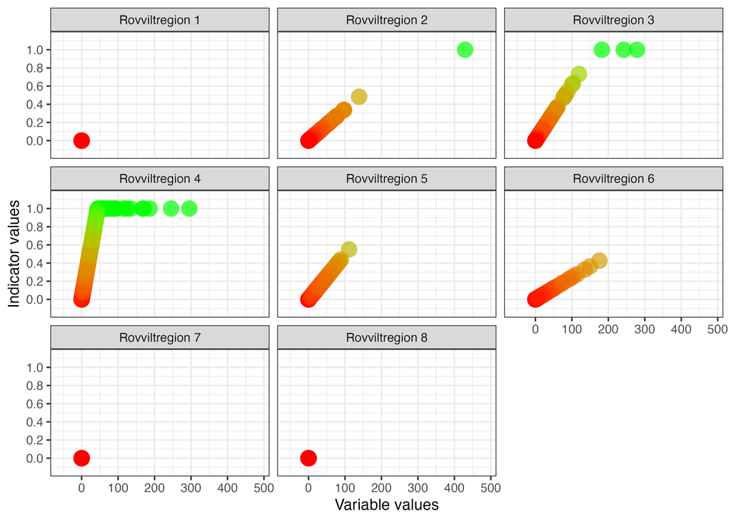

Figure 1: Linear normalisation of wolf population index to indicator values (one panel per management region).

```r
knitr::include_graphics(here::here("img/woab_norm_plot_eng.png"))
```

### Aggregation weights (terrestrial area by management region)

Spatial aggregation uses terrestrial area on each underlying spatial unit in `BSunits`, summed to management region (`ICunitId`). Municipalities are linked to rovvilt regions via `ICunits`. Each management region is assigned to a Naturindeks geographic region (`part`: E, S, W, C, N) with `assign_rovvilt_to_ni()` from `R/spatial_regions.R`.

**Terrestrial area by management region and NI geographic region for weights**

```r
aux <- as_tibble(woabAssemble$BSunits) |>
  rename(BSunitId = id)

IC_BC_link <- woabImport$ICunits |>
  distinct(ICunitId = as.character(id), BSunitId)

aux <- aux |>
  left_join(IC_BC_link, by = join_by(BSunitId))

ic_names <- woabAssemble$indicatorValues[[1]] |>
  transmute(ICunitId = as.character(ICunitId), ICunitName)

aux <- aux |>
  group_by(ICunitId) |>
  summarise(area_weight = sum(terrestrialArea), .groups = "drop") |>
  left_join(ic_names, by = join_by(ICunitId)) |>
  mutate(part = assign_rovvilt_to_ni(ICunitName, output = "part"))

dat <- dat |>
  left_join(aux, by = join_by(ICunitId))
```

### Aggregate to geographic regions (inferential uncertainty)

For each Monte Carlo replicate (b = 1, , 1000) and each geographic region–year, we draw one posterior sample per management region in that area (from that region’s 1000 simulations in `dat`), then compute the terrestrial-area-weighted mean across regions. The resulting 1000 values describe uncertainty around the geographic mean indicator.

**Bootstrap distribution of area-weighted geographic means**

```r
regions <- c("N", "C", "W", "S", "E")
B <- 1000L

out <- tibble(id = seq_len(B))

for (i in regions) {
  for (n in myYears) {
    d_yr <- dat |>
      filter(.data$part == i, .data$year == n)

    mgmt_regions <- sort(unique(d_yr$ICunitId))
    w <- aux |>
      filter(.data$ICunitId %in% mgmt_regions) |>
      arrange(match(.data$ICunitId, mgmt_regions))

    by_region <- split(d_yr$indicator, d_yr$ICunitId)[mgmt_regions]

    col_vals <- vapply(
      seq_len(B),
      function(b) {
        draws <- vapply(by_region, sample, numeric(1), size = 1L)
        stats::weighted.mean(draws, w$area_weight, na.rm = TRUE)
      },
      numeric(1)
    )

    out <- out |>
      add_column(!!paste(i, n, sep = "_") := col_vals)
  }
}
head(out)
```

```
# A tibble: 6 × 31
     id N_1990 N_2000 N_2010 N_2014 N_2019 N_2024    C_1990   C_2000    C_2010
  <int>  <dbl>  <dbl>  <dbl>  <dbl>  <dbl>  <dbl>     <dbl>    <dbl>     <dbl>
1     1      0      0      0      0      0      0 0.00433   0.00219  0.0000441
2     2      0      0      0      0      0      0 0.00736   0.000115 0.00317
3     3      0      0      0      0      0      0 0.00471   0.00151  0.000652
4     4      0      0      0      0      0      0 0.00692   0.00135  0.000164
5     5      0      0      0      0      0      0 0.00235   0.0472   0.000321
6     6      0      0      0      0      0      0 0.0000908 0.00464  0.000489
# ℹ 21 more variables: C_2014 <dbl>, C_2019 <dbl>, C_2024 <dbl>, W_1990 <dbl>,
#   W_2000 <dbl>, W_2010 <dbl>, W_2014 <dbl>, W_2019 <dbl>, W_2024 <dbl>,
#   S_1990 <dbl>, S_2000 <dbl>, S_2010 <dbl>, S_2014 <dbl>, S_2019 <dbl>,
#   S_2024 <dbl>, E_1990 <dbl>, E_2000 <dbl>, E_2010 <dbl>, E_2014 <dbl>,
#   E_2019 <dbl>, E_2024 <dbl>
```

### Aggregate to national level (inferential uncertainty)

For each year and replicate (b), the national value is the terrestrial-area-weighted mean of the five geographic regional values from that same replicate (`aux2` gives total area per geographic region). This propagates uncertainty to the national mean in the same way as at geographic scale.

**Bootstrap distribution of area-weighted national means**

```r
aux2 <- aux |>
  group_by(part) |>
  summarise(area_weight = sum(.data$area_weight), .groups = "drop")

w_region <- aux2$area_weight[match(regions, aux2$part)]

out2 <- tibble(id = seq_len(B))

for (n in myYears) {
  nat_vals <- vapply(
    seq_len(B),
    function(b) {
      reg_draws <- vapply(
        regions,
        function(r) out[[paste(r, n, sep = "_")]][b],
        numeric(1)
      )
      stats::weighted.mean(reg_draws, w_region, na.rm = TRUE)
    },
    numeric(1)
  )

  out2 <- out2 |>
    add_column(!!paste("All", n, sep = "_") := nat_vals)
}

head(out2)
```

```
# A tibble: 6 × 7
     id All_1990 All_2000 All_2010 All_2014 All_2019 All_2024
  <int>    <dbl>    <dbl>    <dbl>    <dbl>    <dbl>    <dbl>
1     1  0.00488  0.00558  0.00971   0.0230   0.0347   0.0354
2     2  0.00323  0.00409  0.0272    0.0285   0.0363   0.0365
3     3  0.00267  0.00625  0.0136    0.0237   0.0390   0.0466
4     4  0.00192  0.00569  0.0160    0.0295   0.0350   0.0294
5     5  0.00244  0.0132   0.0261    0.0265   0.0372   0.0287
6     6  0.00222  0.0192   0.0152    0.0277   0.0375   0.0315
```

**Bootstrap distribution of area-weighted national means**

```r
out <- out |>
  bind_cols(out2 |> select(-id))
```

## 10. Results

```r
summary_out <- out |>
  pivot_longer(cols = !any_of("id")) |>
  separate_wider_delim(cols = name, delim = "_", names = c("part", "year")) |>
  group_by(part, year) |>
  summarise(
    median = round(median(value, na.rm = TRUE), 2),
    p_025 = round(quantile(value, probs = 0.0025, na.rm = TRUE), 2),
    p_25 = round(quantile(value, probs = 0.25, na.rm = TRUE), 2),
    p_75 = round(quantile(value, probs = 0.75, na.rm = TRUE), 2),
    p_975 = round(quantile(value, probs = 0.975, na.rm = TRUE), 2),
  ) |>
  add_column(
    ECT = "B3",
    Indicator = "Wolf abundance",
    Ecosystem = "Boreal/montane forests",
    ID = "NO_WOAB_001"
  ) |>
  mutate(
    part = case_when(
      part == "All" ~ "Norway",
      part == "N" ~ "North",
      part == "C" ~ "Central",
      part == "W" ~ "West",
      part == "S" ~ "South",
      part == "E" ~ "East",
      TRUE ~ part
    )
  )
```

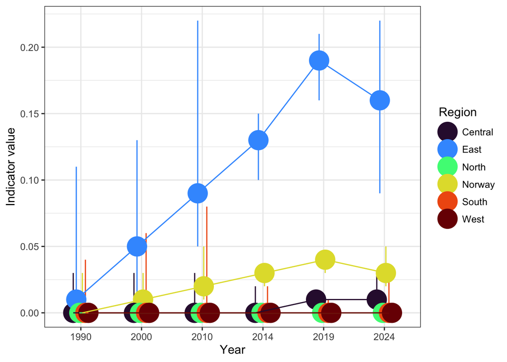

Figure 2: Indicator values for wolf abundance by geographic region and nationally, with uncertainty bands from the resampled distribution.

```r
summary_out |>
  ggplot(aes(x = year, y = median, colour = part, group = part)) +
  geom_pointrange(
    aes(ymin = p_025, ymax = p_975),
    size = 2,
    position = position_dodge(width = 0.3)
  ) +
  geom_line(position = position_dodge(width = 0.3)) +
  theme_bw(base_size = 12) +
  labs(y = "Indicator value", x = "Year") +
  scale_colour_viridis_d(option = "turbo", name = "Region")
```

```r
summary_out |>
  unite(col = "CI_95", c(p_025, p_975), sep = " - ") |>
  unite(col = "IQR", c(p_25, p_75), sep = " - ") |>
  select(
    ECT,
    Indicator,
    ID,
    "Accounting area" = part,
    Ecosystem,
    "Closing year" = year,
    "Indicator value" = median,
    "95% CI" = CI_95,
    "50% CI" = IQR
  ) |>
  kable()
```

Table 2: Indicator values and uncertainty estimates for wolf abundance.

| ECT | Indicator | ID | Accounting area | Ecosystem | Closing year | Indicator value | 95% CI | 50% CI |
| --- | --- | --- | --- | --- | --- | --- | --- | --- |
| B3 | Wolf abundance | NO_WOAB_001 | Norway | Boreal/montane forests | 1990 | 0.00 | 0 - 0.03 | 0 - 0.01 |
| B3 | Wolf abundance | NO_WOAB_001 | Norway | Boreal/montane forests | 2000 | 0.01 | 0 - 0.03 | 0.01 - 0.01 |
| B3 | Wolf abundance | NO_WOAB_001 | Norway | Boreal/montane forests | 2010 | 0.02 | 0.01 - 0.05 | 0.02 - 0.02 |
| B3 | Wolf abundance | NO_WOAB_001 | Norway | Boreal/montane forests | 2014 | 0.03 | 0.02 - 0.03 | 0.02 - 0.03 |
| B3 | Wolf abundance | NO_WOAB_001 | Norway | Boreal/montane forests | 2019 | 0.04 | 0.03 - 0.04 | 0.04 - 0.04 |
| B3 | Wolf abundance | NO_WOAB_001 | Norway | Boreal/montane forests | 2024 | 0.03 | 0.02 - 0.05 | 0.03 - 0.04 |
| B3 | Wolf abundance | NO_WOAB_001 | Central | Boreal/montane forests | 1990 | 0.00 | 0 - 0.03 | 0 - 0 |
| B3 | Wolf abundance | NO_WOAB_001 | Central | Boreal/montane forests | 2000 | 0.00 | 0 - 0.03 | 0 - 0 |
| B3 | Wolf abundance | NO_WOAB_001 | Central | Boreal/montane forests | 2010 | 0.00 | 0 - 0.03 | 0 - 0 |
| B3 | Wolf abundance | NO_WOAB_001 | Central | Boreal/montane forests | 2014 | 0.00 | 0 - 0.02 | 0 - 0.01 |
| B3 | Wolf abundance | NO_WOAB_001 | Central | Boreal/montane forests | 2019 | 0.01 | 0 - 0.01 | 0 - 0.01 |
| B3 | Wolf abundance | NO_WOAB_001 | Central | Boreal/montane forests | 2024 | 0.01 | 0 - 0.03 | 0 - 0.01 |
| B3 | Wolf abundance | NO_WOAB_001 | East | Boreal/montane forests | 1990 | 0.01 | 0 - 0.11 | 0 - 0.02 |
| B3 | Wolf abundance | NO_WOAB_001 | East | Boreal/montane forests | 2000 | 0.05 | 0.01 - 0.13 | 0.03 - 0.07 |
| B3 | Wolf abundance | NO_WOAB_001 | East | Boreal/montane forests | 2010 | 0.09 | 0.05 - 0.22 | 0.07 - 0.12 |
| B3 | Wolf abundance | NO_WOAB_001 | East | Boreal/montane forests | 2014 | 0.13 | 0.1 - 0.15 | 0.12 - 0.13 |
| B3 | Wolf abundance | NO_WOAB_001 | East | Boreal/montane forests | 2019 | 0.19 | 0.16 - 0.21 | 0.18 - 0.2 |
| B3 | Wolf abundance | NO_WOAB_001 | East | Boreal/montane forests | 2024 | 0.16 | 0.09 - 0.22 | 0.14 - 0.18 |
| B3 | Wolf abundance | NO_WOAB_001 | North | Boreal/montane forests | 1990 | 0.00 | 0 - 0 | 0 - 0 |
| B3 | Wolf abundance | NO_WOAB_001 | North | Boreal/montane forests | 2000 | 0.00 | 0 - 0 | 0 - 0 |
| B3 | Wolf abundance | NO_WOAB_001 | North | Boreal/montane forests | 2010 | 0.00 | 0 - 0 | 0 - 0 |
| B3 | Wolf abundance | NO_WOAB_001 | North | Boreal/montane forests | 2014 | 0.00 | 0 - 0 | 0 - 0 |
| B3 | Wolf abundance | NO_WOAB_001 | North | Boreal/montane forests | 2019 | 0.00 | 0 - 0 | 0 - 0 |
| B3 | Wolf abundance | NO_WOAB_001 | North | Boreal/montane forests | 2024 | 0.00 | 0 - 0 | 0 - 0 |
| B3 | Wolf abundance | NO_WOAB_001 | South | Boreal/montane forests | 1990 | 0.00 | 0 - 0.04 | 0 - 0.01 |
| B3 | Wolf abundance | NO_WOAB_001 | South | Boreal/montane forests | 2000 | 0.00 | 0 - 0.06 | 0 - 0 |
| B3 | Wolf abundance | NO_WOAB_001 | South | Boreal/montane forests | 2010 | 0.00 | 0 - 0.08 | 0 - 0.01 |
| B3 | Wolf abundance | NO_WOAB_001 | South | Boreal/montane forests | 2014 | 0.00 | 0 - 0.02 | 0 - 0.01 |
| B3 | Wolf abundance | NO_WOAB_001 | South | Boreal/montane forests | 2019 | 0.00 | 0 - 0.01 | 0 - 0 |
| B3 | Wolf abundance | NO_WOAB_001 | South | Boreal/montane forests | 2024 | 0.00 | 0 - 0.03 | 0 - 0.01 |
| B3 | Wolf abundance | NO_WOAB_001 | West | Boreal/montane forests | 1990 | 0.00 | 0 - 0 | 0 - 0 |
| B3 | Wolf abundance | NO_WOAB_001 | West | Boreal/montane forests | 2000 | 0.00 | 0 - 0 | 0 - 0 |
| B3 | Wolf abundance | NO_WOAB_001 | West | Boreal/montane forests | 2010 | 0.00 | 0 - 0 | 0 - 0 |
| B3 | Wolf abundance | NO_WOAB_001 | West | Boreal/montane forests | 2014 | 0.00 | 0 - 0 | 0 - 0 |
| B3 | Wolf abundance | NO_WOAB_001 | West | Boreal/montane forests | 2019 | 0.00 | 0 - 0 | 0 - 0 |
| B3 | Wolf abundance | NO_WOAB_001 | West | Boreal/montane forests | 2024 | 0.00 | 0 - 0 | 0 - 0 |

## 11. Export file

**Export resampled indicator draws**

```r
write.csv(out, here::here("data/results_NO_WOAB_001_v0.1.0.csv"), row.names = FALSE)
```

## 12. Author contributions

Not relevant, as this is the work of a single author. I would, however, like to acknowledge the work of those that created the indicator on *Naturindeks* (Norwegian Institute for Nature Research and partners 2025).

**TipSession Info**